# Class 9: Aspects of Social Movement Activity

Social movement coalitions

[Dr. Michael C. Zeller](https://michaelzeller.de)

# Opening notes

[Open Sticker](https://tenor.com/view/open-gif-14209777)from [Open Stickers](https://tenor.com/search/open-stickers)

## Presentation groups

- December
- January

Presentations line-up

| Date | Presenters | Method |
| --- | --- | --- |
| 4 Dec: |  | TBD |
| 11 Dec: |  | TBD |
| 18 Dec: |  | TBD |

Presentations line-up

| Date | Presenters | Method |
| --- | --- | --- |
| 8 Jan: |  | TBD |
| 15 Jan: |  | TBD |
| 22 Jan: |  | TBD |
| 29 Jan: |  | TBD |

# State responses

- opening questions
- overview
- one policy change example
- repression/social control
- DE state responses to climate movement
  - FFF and LG

[Alf Excellent Response GIF](https://tenor.com/view/alf-excellent-response-good-response-good-answer-great-response-gif-26121622)from [Alf GIFs](https://tenor.com/search/alf-gifs)

## Opening questions

How (in what different ways) can state actors respond to movements?

Who/which state actor is taking action? What kind of action is it? How visible is it?

## State responses overview

- ignore / dismiss
- oppose
- accommodate

## State responses overview

- ignore / dismiss
- oppose
  - close opportunities (‘problem depletion’)
  - ‘channel’, restrict access to resources
  - repress, apply force
- accommodate
  - encourage institutionalisation
  - engage in relevant decision-making processes
  - change policy

## One policy change example (Jones 2022)

anyone know what this place is?

[figure not shown]

## One policy change example (Jones 2022)

- Valley of the Fallen (incl., Catholic basilica), outside Madrid
- monument constructed under Franco, using forced/convict labour
- burial place for Franco (exhumed 24.10.2019) and Primo de Rivera (exhumed 23.4.2023)
- *Ley de Memoria Histórica*:

[figure not shown]

> recognises and broadens “the rights and establishes measures in favour of those who suffered persecution or violence during the civil war and the dictatorship.”

## 3 dimensions of repression/social control (Earl 2003)

| Identity of repressive agent | State agents tightly connected with national political elites (e.g., military units) | State agents loosely connected with national political elites (e.g., local police departments) | Private agents (e.g., counter-demonstrators) |
| --- | --- | --- | --- |
| Character of repressive action | Coercion (e.g., use of tear gas and rubber bullets) | Channelling (e.g., restrictions on registered organisations) |  |
| Whether repressive action is observable | Observable (i.e., overt; e.g., Tiananmen Square) | Unobserved (i.e., covert or latent; e.g., COINTELPRO) |  |

What sort of repression/social control in cases do you know of? Was it effective? Why/How?

## DE climate movement - FFF

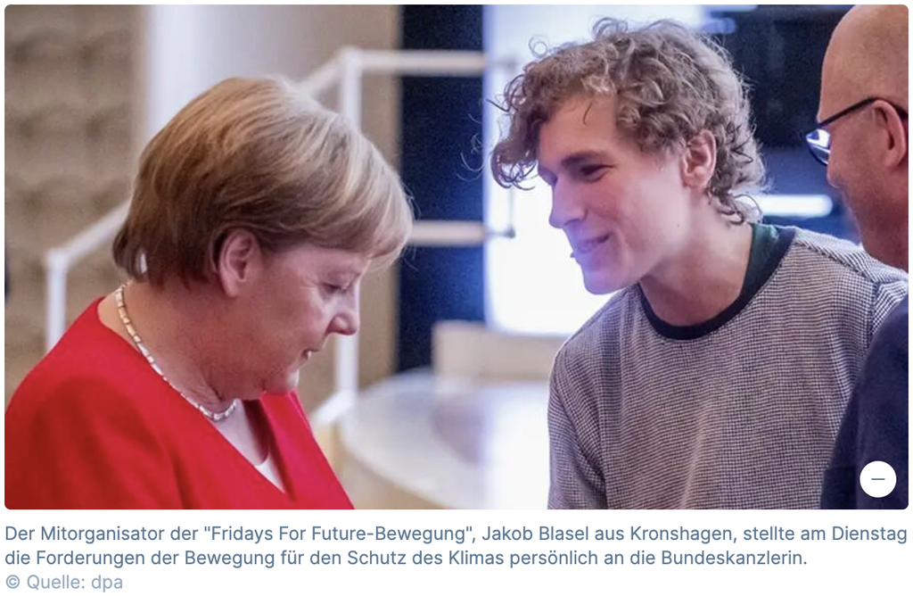

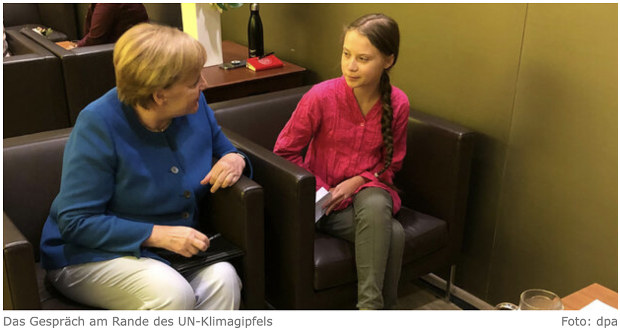

- March 2019: Chancellor Merkel praises FFF ([link](https://www.spiegel.de/lebenundlernen/schule/angela-merkel-bekraeftigt-lob-fuer-fridays-for-future-a-1260875.html))
- April 2019: government minister (for Economy and Energy, Peter Altmeier) requests to speak at FFF demo (rejected by organisers) ([link](https://www.spiegel.de/wirtschaft/soziales/fridays-for-future-peter-altmaier-will-mit-streikenden-schuelern-reden-a-1249839.html))
- August 2020: Chancellor Merkel meets with FFF representatives ([link](https://www.bundesregierung.de/breg-de/schwerpunkte/klimaschutz/bundeskanzlerin-merkel-trifft-vertreterinnen-von-fridays-for-future-1778472?view=renderNewsletterHtml))
- March 2021: constitutional court (*Bundesverfassungsgericht*) declares federal climate protection law (*Bundes-Klimaschutzgesetz*) insufficient, requiring more goverment action
- influence on United Nations Climate Change conferences, COPs 25-28

## DE climate movement - Letzte Generation

- 2022: Green party (potential elite allies) distance themselves from LG
- December 2022/May 2023: police searches of LG properties, related to prosecutions ([link](https://www.dw.com/en/german-police-launch-raids-against-last-generation-activists/a-64078503) and [link](https://www.dw.com/en/german-police-swoop-on-last-generation-climate-activists/a-65715954))

[figure not shown]

- April 2023: violent police tactics to remove blockaders ([link](https://zeit.de/gesellschaft/2023-04/polizei-berlin-gewalt-letzte-generation-klimaprotest))
  - ‘pain grips’ (*Schmerzgriffe*): wristlocks and other ‘control/restraint holds’
- use of **preventive detention** in Bayern ([link](https://voelkerrechtsblog.org/preventive-detention-under-the-convention/)) and calls for it elsewhere by police union chief ([link](https://www.theguardian.com/world/2023/apr/27/german-police-call-for-tougher-response-to-growing-climate-protests-letzte-generation))
- politicians, some from governing parties, refering to ‘climate terrorists’ (*Klimaterroristen*) and ‘climate RAF’ (*Klima-RAF*)

# Poll: State responses

[figure not shown]

Take the survey at **https://forms.gle/jkBAGEAx5Ub9LeoT6**

- good when state agrees to protest demands?
- non-violent protest inviolable?
- state response to movement disruption of services?
- is state surveillance of a movement ever acceptable?
- what determines whether movement treated as ‘threatening’?
- what typically happens after a state violently represses a movement?
- states respond more harshly to ‘marginalised group’ movements?

[interactive chart not shown]

good when state agrees to protest demands?

[interactive chart not shown]

determines whether movement treated as ‘threatening’?

[interactive chart not shown]

## Poll - harder state responses

state response to movement disruption of services?

[interactive chart not shown]

state surveillance of a movement ever acceptable?

[interactive chart not shown]

If yes, when?

what after a state violently represses a movement?

[interactive chart not shown]

## Poll - motivated state responses

states respond more harshly to ‘marginalised group’ movements?

[interactive chart not shown]

non-violent protest inviolable?

[interactive chart not shown]

Even if protest is anti-democratic/ hateful/discriminatory?

# Research closer look

- Berntzen and Weisskircher (2016) - mobilisation differences and state responses
  - PEGIDA background
  - research questions and design
  - cases and data collection
  - findings
  - discussion question

[Closer Look GIF](https://tenor.com/view/closer-look-gif-19341620)from [Closer GIFs](https://tenor.com/search/closer-gifs)

## PEGIDA background: movement framing

**PEGIDA as a ‘serious civil rights movement’? (*H.C. Strache*)**

## PEGIDA background: a demonstration in Wien

Wien, 2 February 2015

[video not shown]

## Berntzen and Weisskircher (2016) - RQ

- *why did PEGIDA mobilize to some extent in Austria and Norway, while failing in Sweden and Switzerland?*

**case selection**: two countries from economically and culturally similar regions (German-speaking Central Europe [Switzerland and Austria] and Scandinavia [Norway and Sweden]), each with variation on the ‘dependent variable’ of street mobilisation

- sort of paired ‘most similar systems design’ (MSSD)
- key IVs: state bans, parliamentary strength of the radical right, counter-mobilisation by anti-racist groups
  - **why these IVs? are there other important factors? what are the hypothesised effects?**

## Berntzen and Weisskircher (2016) - cases

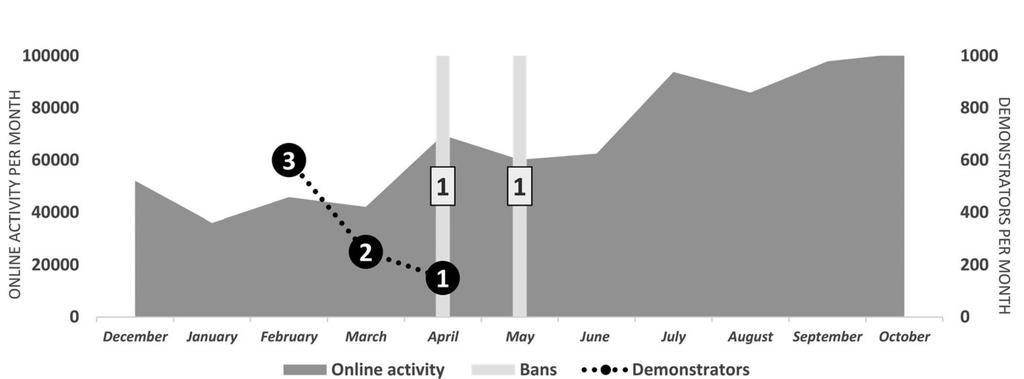

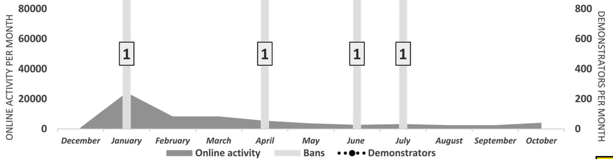

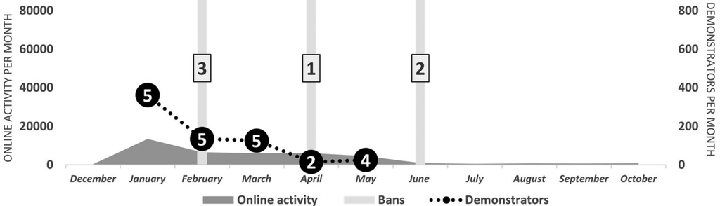

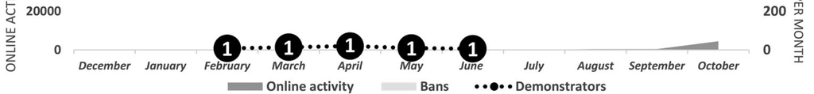

thickness of grey stream shows aggregate online activity by PEGIDA groups. Circles indicate protesters in month, number inside circle shows demos per month

**Austria**: significant mobilisation

**Switzerland**: insignificant mobilisation

**Norway**: significant mobilisation

**Sweden**: insignificant mobilisation

## Berntzen and Weisskircher (2016) - data collection

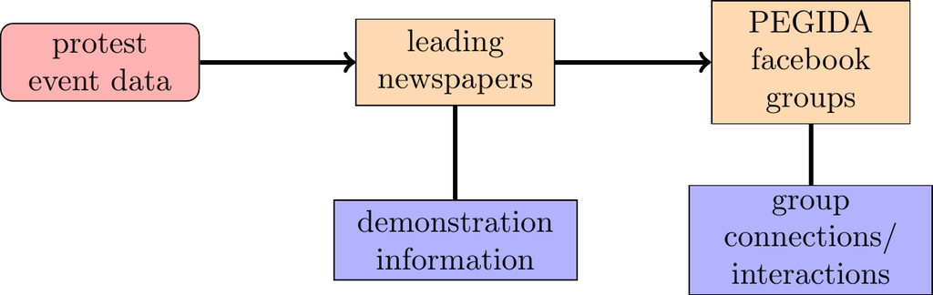

**gaps in this data collection? anything other data needed?**

## PEGIDA Facebook memberships

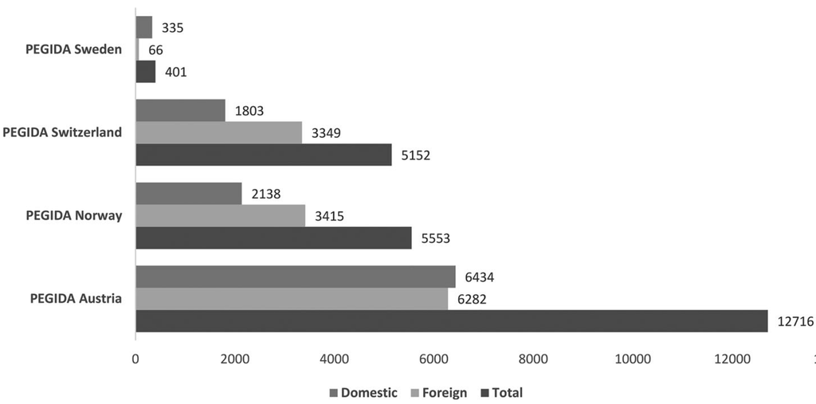

## Berntzen and Weisskircher (2016) - findings

> “it is possible that the massive level of resistance has curtailed PEGIDA to a certain extent by making it costlier for people to march under their banner. Nevertheless, this cannot explain cross-national variation as anti-racists mobilised strongly in all four countries”

## Berntzen and Weisskircher (2016) - network

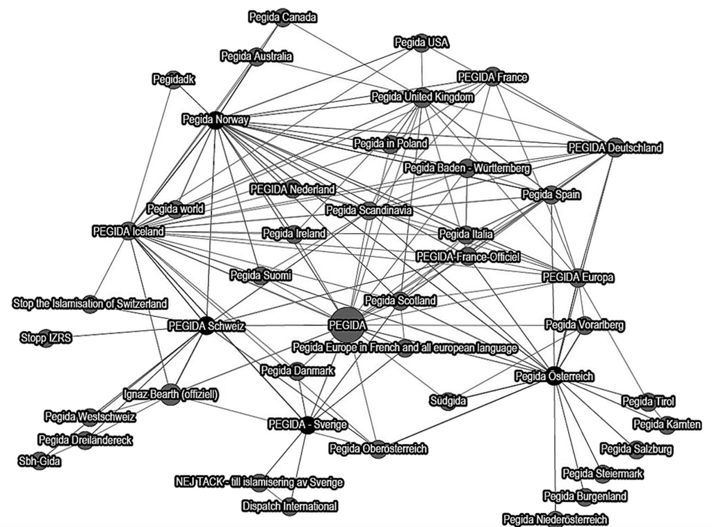

## Berntzen and Weisskircher (2016) - findings

> Attempts to **mobilise and spread propaganda online** by the transnational radical right are therefore **vulnerable to police and state bans**, especially if they are **put in place at an early stage** in their mobilisation efforts. This lays bare the potential for curtailing far-right activism in multiple arenas by targeting and denying them the opportunity of rallying and getting attention through street activism.

## Berntzen and Weisskircher (2016) - findings

- **Sweden PEGIDA**: restrictively policed due to high counter-mobilisation
  - new mobilisation: no strong benefit of pre-existing radical right activism; in all other cases, *PEGIDA label* was used by established radical right actors
- **Switzerland PEGIDA**: protests banned by local authorities
  - banning demonstrations (offline) also negatively impacted online activism
- **Norway PEGIDA**: outgrowth of pre-existing radical right activism
  - bans on demonstrations in Oslo—also negatively impacted online activism
- **Austria PEGIDA**: deeply embedded in national and transnational far-right scene, some support from FPÖ (large, radical right political party)
  - establishing stable online presence reshapes (expands) online far-right scene
- counter-mobilisation and radical right party strength do not explain differences in mobilisation—state action (esp. banning) does
  - are you convinced by this?

## Berntzen and Weisskircher (2016) - discussion question

> All PEGIDA events in Austria were met with much greater countermobilisation. Some PEGIDA activists were reported to the police because of engagement in National Socialist activities, such as Hitler salutes.

Is counter-mobilisation needed to provoke a state response?

some random researcher strongly contending ‘yes’: Zeller (2021), Zeller (2022), Zeller and Vaughan (2024), Zeller (2025)

to be continued with next session, on ‘counter-mobilisation’

# Any questions, concerns, feedback for this class?

Anonymous feedback here: https://forms.gle/AjHt6fcnwZxkSg4X8

Alternatively, please send me an email: m.zeller@lmu.de

## References

Berntzen, Lars Erik, and Manès Weisskircher. 2016. “Anti-Islamic PEGIDA Beyond Germany: Explaining Differences in Mobilisation.” *Journal of Intercultural Studies* 37 (6): 556–73. https://doi.org/10.1080/07256868.2016.1235021.

Earl, Jennifer. 2003. “Tanks, Tear Gas, and Taxes : Toward a Theory of Movement Repression.” *Sociological Theory* 21 (1): 44–68.

Jones, Sam. 2022. “Spanish Fascist’s Family to Exhume Remains from Valley of the Fallen.” *The Guardian*, October, 2.

Zeller, Michael C. 2021. “Patterns of Demobilization: A Qualitative Comparative Analysis (QCA) of Far-Right Demonstration Campaigns.” *Mobilization: An International Quarterly* 26 (3): 267–84. https://doi.org/10.17813/1086-671X-26-3-267.

———. 2022. “Demobilising Far-Right Demonstration Campaigns: Coercive Counter-Mobilisation, State Social Control, and the Demobilisation of the Hess Gedenkmarsch Campaign.” *Social Movement Studies* 21 (3): 372–90. https://doi.org/10.1080/14742837.2021.1889493.

———. 2025. “Pragmatic Rather Than Principled: Organisational Bans in Democracies.” *European Journal of Political Research* 0 (0): 1–30. https://doi.org/10.1017/S1475676525100121y.

Zeller, Michael C, and Michael Vaughan. 2024. “Proscribing Right-Wing Extremist Organizations in Europe: Variations, Trends, and Prospects.” *Terrorism and Political Violence* 36 (8): 985–1007. https://doi.org/10.1080/09546553.2023.2240446.